# Designing experiments for global rollout

Multi-arm designs for the GATE under partial interference

Molly Offer-Westort (Chicago) · **Drew Dimmery** (Hertie School)

2026-09-24

## Tuning video playback at Meta

[figure not shown]

Buffering harder for one video starves the next, so configurations interfere. The decision is a single configuration, shipped to everyone.

## Optimization needs a good model

[figure not shown]

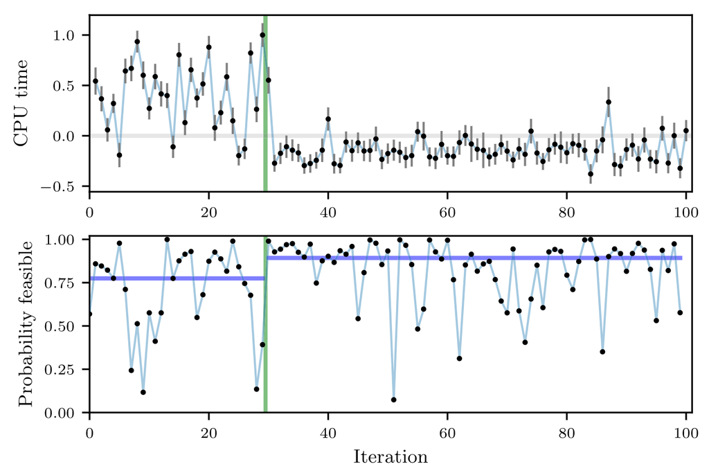

The same intervention, similar measure, radically different ability to optimize.

- User-level precision grows only with the user base
- Finer grain splits the users you have
- How fine can we go?

Right panel: Figure 6 of Letham, Karrer, Ottoni & Bakshy (2019), “Constrained Bayesian Optimization with Noisy Experiments,” *Bayesian Analysis* 14(2).

## We care about rollout

Sessions $j$, videos $i$, arms $A_{j,i} \in \{0,\ldots,M\}$ with $0$ the control.

- **Partial interference**: $Y_{j,i}$ depends on the arms inside session $j$ only.

Two questions about arm $m$:

1. what it does to switch for **one video**,
2. or switch **every video, for every user**?
- Only the second is shippable — the Global Average Treatment Effect:

$$\Psi_m^{\mathrm{GATE}} \;=\; \mathbb{E}\Big[\, \underbrace{Y_{j,i}(\bar{\mathbf m}_j)}_{\substack{\text{every video}\\ \text{on arm } m}} \;-\; \underbrace{Y_{j,i}(\bar{\mathbf 0}_j)}_{\substack{\text{every video}\\ \text{on control}}} \,\Big]$$

The first depends on the mix your experiment happened to create: a world nobody will live in.

## Two standard designs, two problems

|  | Bias for the GATE | Precision |
| --- | --- | --- |
| **Cluster-uniform** — all videos for a user/session get one arm | Unbiased | You have as many observations as *users/sessions* |
| **Unit-level** — each video assigned independently | Biased | Every *video* counts |

They differ in one thing: the **within-session treatment correlation** $\rho_T$: one, or zero.

Unit-level designs are precise for the wrong estimand: a “low-data” video is surrounded by a *mixture*.

## Both problems are visible in the data

[figure not shown]

Cluster-uniform: ~3× the SEs. Unit-level: ~1.5× the effect magnitudes.

## These designs exist in a continuum

[figure not shown]

Our work examines the middle column.

## Why an endpoint is rarely optimal

Moulton (1986): correlated assignment inflates the variance by

$$1 + \hlblue{\rho_T}\,\hlred{\rho_u}\,(\hlgreen{\bar N} - 1)$$

It is a **product**: what the treatment correlation you impose *costs* is set by the outcome correlation you inherit. At $\hlred{\rho_u} \approx 0$ it is free.

[figure not shown]

Bias runs the other way. So a good choice of $\hlblue{\rho_T}$ depends on $\hlred{\rho_u}$ and $\hlgreen{\bar N}$.

## One knob, not discrete choice

**Per session,** draw a mix over arms — 70% arm 3, 20% control, … — then assign each video from it:

$$\underbrace{\Pi_j \sim \mathrm{Dirichlet}(\bar\alpha,\ldots,\bar\alpha)}_{\text{one mix per session}}, \qquad \underbrace{\Pr\big[A_{j,i} = m \mid \Pi_j\big] = \Pi_j[m]}_{\text{videos i.i.d. given the mix}}$$

The whole design choice is one **concentration** parameter: $\rho_T(\bar\alpha) = 1/[(M{+}1)\bar\alpha+1]$.

| $\bar\alpha \to 0$ | interior | $\bar\alpha \to \infty$ |
| --- | --- | --- |
| lopsided mixes, $\rho_T \to 1$ | anything in between | balanced mixes, $\rho_T \to 0$ |
| = cluster-uniform | **our work** | = unit-level |

## Smoothly varying design choices

[figure not shown]

The family embeds both standard designs as its endpoints.

## The workflow

[figure not shown]

The pilot is exploratory: it picks a region of the dial, not the GATE.

Step 3 loops on itself at the same tuned $\bar\alpha$ — that is where the optimization happens.

## The workflow

[figure not shown]

Nothing here is specific to the GATE or to RMSE: swap the target contrast or the loss, and the machinery is unchanged.

## Step 1: Pilot

One concurrent pilot, split across a few prespecified $\bar\alpha$ so realized shares vary. Three outputs:

1. the **cluster size distribution** $\{N_j\}$: mean and variance
2. the **variance components**: total variance $\sigma^2 + \tau^2$, and the outcome correlation $\rho_u = \tau^2/(\sigma^2+\tau^2)$
3. a parsimonious summary of **interference**

## One modelling ingredient

How a video’s outcome responds to **its own arm** and to **the mix around it**, the realized shares $p_{j[\ell]}$ of session $j$ on arm $\ell$:

$$\mathbb{E}\big[\,Y_{j,i} \,\big|\, A_{j,i} = m,\ \mathbf p_j\,\big] \;=\; \underbrace{\beta_m}_{\text{own arm}} \;+\; \underbrace{\textstyle\sum_{\ell} \delta_{m,\ell}\, p_{j[\ell]}}_{\substack{\text{linear in the shares}\\ \text{around you}}}$$

Under a **uniform rollout** $p_{j[m]} = 1$, so

$$\Psi_m^{\mathrm{GATE}} \;=\; (\beta_m + \delta_{m,m}) - \beta_0$$

We are not asking this model for correct specification. It is a working model, used to calibrate a design.

$(M{+}1)^2$ mean parameters: 121 for our 10 treatment groups and control. For us: one slope, on the share of “high-data” videos.

Linear-in-means: Manski (1993); Bramoullé, Djebbari & Fortin (2009). Interference regressions: Chin (2018); Baird, Bohren, McIntosh & Özler (2018).

## Step 2 — Tune

Score each candidate design by its expected RMSE, and take the argmin:

$$\bar\alpha^\star \;\in\; \arg\min_{\bar\alpha}\ \frac{1}{M}\sum_{m=1}^{M}\Big\{\widehat{\mathrm{Bias}}_m(\bar\alpha)^2 + \widehat{\mathrm{Var}}_m(\bar\alpha)\Big\}^{1/2}$$

#### Bias — closed form

Substitute the pilot’s $\widehat\delta$ into the exposure moments: $\widehat{\mathrm{Bias}}_m$ is arithmetic in $(\widehat\delta,\ \bar\alpha,\ \{N_j\})$. No simulation.

#### Variance — design replay

Simulate the experiment with the working model and take the variance of $\widehat\Psi_m$ across replications.

Bias depends only on the mean mix a video sees; variance depends on the whole joint draw.

Both terms are computed for the estimator being tuned, so the same calculation ranks **estimators** as well as designs.

## Design replay

[figure not shown]

Conditioning on the pilot estimates, simulate each candidate $\bar\alpha$ and read off the estimator’s spread.

## Steps 3 and 4 — Run, then validate

#### 3. Main run

Fresh clusters at the tuned design, with a prespecified decision rule.

Where the precision pays: more arms screened, faster, with rankings you can act on.

#### 4. Validation

A cluster-uniform experiment, on the selected arm(s) only.

Coverage for the GATE is generally not correct at interior designs, so the headline number comes from here.

**Search**, then **claim**.

- Different stages in an experiment may have different bias-variance tradeoffs that make sense!

## What we ran at Meta

**Pilot**: two 2018 experiments

|  | estimate |
| --- | --- |
| $\rho_u$ | 0.10 |
| SE, user-level | 0.0052 |
| SE, user–video | 0.0018 |
| magnitude ratio | 1.46 |
| $\bar N$ | 9.25 |
| $\mathrm{Var}(N_j)$ | 282.3 |

**Main run**: at the tuned design

- 30 configurations over five continuous parameters
- per-session Dirichlet draws were infeasible at scale, so a small **library** of quasi-random mixes, one per session
- the variance reduction is what made the **optimization loop** workable
- validated session-level: stalls down, nothing else degraded

## Bias falls and variance rises along the dial

100 clusters × 50 units · three arms (control, high, low) · 1,000 replications

[figure not shown]

Difference-in-means with weak interference ($c = 0.1$). $\rho_T = 1$: cluster-uniform; $\rho_T = 0$: unit-level.

As $\rho_u$ rises, the best design slides from nearly cluster-uniform to nearly unit-level.

## Difference-in-means can beat the correct model

[figure not shown]

- The linear model is **correctly specified**, and still loses to difference-in-means
  - it pays variance for every exposure slope it has to estimate (and there are many).

## Bigger picture

1. **Pilot, tune, run, validate.**
- Different phases deserve different designs!
- Offer-Westort: *Explore-Confirm Designs for Testing Intervention Families*
  - You can generate valid tests over multi-phase designs
2. Research *programs* also benefit from thinking sequentially
- Are we in an *exploration* phase or a *validation* phase?
3. Experimentation is a powerful *optimization* tool
- Dimmery: *Social Science without Generalization*
  - Internal validity is sufficient for many important problems

# Thank you!

d.dimmery@hertie-school.org

QR code linking to the paper on arXiv

[`arXiv:2101.12318`](https://arxiv.org/abs/2101.12318)